# Topic structure of the COVID-19 education literature as a document-word hypergraph

honets

2026-09-06

## Text cleaning

`clean_text()` removes the non-content that a bibliographic export carries in its abstracts. It decodes HTML entities, strips tags, normalises typographic characters, and removes bracketed citation numbers, list markers, URLs, DOIs, trailing copyright notices and bare numbers. It takes a character vector or a data frame with a text column and returns an object of the same length or the same rows. A text whose share of alphabetic characters falls below `min_content` is replaced by the empty string. The `remove` argument takes additional patterns; here it names the placeholder that Scopus inserts for a missing abstract.

```r
abstracts <- clean_text(sbert::covid, column = "Abstract",
                        remove = "no abstract available", min_content = 0.5)
abstracts <- unique(abstracts)
```

The result is a data frame with the same columns as the input. The 323 placeholder rows and four low-content rows now hold empty abstracts, and `unique()` has collapsed the records that appear twice in the export. Empty abstracts are retained at this stage so that the year column stays aligned with the text.

## Hypergraph construction

`text_hypergraph()` builds a weighted hypergraph from a corpus. With the default `construction = "bag"` and `nodes = "doc"`, each document is a node and each word is a hyperedge that contains every document using the word. With the default `weight = "n"`, the incidence cell of a document and a word is the count of the word in the document. Tokens are lower-cased alphabetic strings, so numbers do not enter the vocabulary. Documents without any remaining token are dropped with a warning.

```r
stops <- c(stop_words_en(), "covid", "pandemic")
hg <- text_hypergraph(abstracts, column = "Abstract", stop_words = stops,
                      min_count = 5L)
hg
```

```
Text hypergraph: 3666 documents, 6247 words (documents as nodes, weight = n)
Hyperedges: 6247 (words); sizes 1-2595, median 14
```

The stop list contains the English function words of `stop_words_en()` and the two words that name the subject of every abstract; a word present in every document does not separate any two documents. Words used in fewer than five abstracts are excluded by `min_count`. The incidence matrix has more than a million cells, so the default `sparse = NULL` stores it as a sparse matrix.

## Number of topics

`hg_cluster()` with `what = "eigenvalues"` returns the leading eigenvalues of the normalised hypergraph Laplacian (Zhou, Huang and Schölkopf, 2007) and the gap after each. A large gap between consecutive eigenvalues indicates a partition that the structure supports.

```r
hg_cluster(hg, k = 18, seed = 1, what = "eigenvalues")
```

```
   index     value          gap
1      1 0.0000000 0.8114861934
2      2 0.8114862 0.0480150385
3      3 0.8595012 0.0084016439
4      4 0.8679029 0.0178366097
5      5 0.8857395 0.0052953819
6      6 0.8910349 0.0061783427
7      7 0.8972132 0.0007323411
8      8 0.8979456 0.0054123890
9      9 0.9033579 0.0044682780
10    10 0.9078262 0.0003454305
11    11 0.9081716 0.0038469940
12    12 0.9120186 0.0006692869
13    13 0.9126879 0.0009552955
14    14 0.9136432 0.0013974914
15    15 0.9150407 0.0008815482
16    16 0.9159223 0.0024931240
17    17 0.9184154 0.0012476645
18    18 0.9196631 0.0005545092
19    19 0.9202176           NA
```

## Partition

`hg_cluster()` embeds the documents in the leading eigenvectors of the Laplacian and partitions the embedding with k-means. With the default `type = "zhou"` the Laplacian is built from hyperedge membership alone: each hyperedge has unit weight and the incidence cells are not read. The function takes the hypergraph, the number of clusters and a seed, and returns a data frame with one row per document and its cluster label.

```r
topics <- hg_cluster(hg, k = 16, seed = 1)
head(topics)
```

```
      node   cluster
1    doc_1 Cluster 1
2   doc_10 Cluster 2
3  doc_100 Cluster 3
4 doc_1000 Cluster 4
5 doc_1001 Cluster 2
6 doc_1002 Cluster 5
```

## Topic description

`hg_keywords()` ranks the words of each cluster. It takes the hypergraph and the partition and returns a data frame with one row per cluster and word, containing the score, the word’s share and the number of cluster documents that contain the word. The print method shows one row per cluster with its words joined; `as.data.frame()` returns the long form. The default score, `type = "mass"`, is the summed incidence weight that a cluster’s documents place on the word, which under `weight = "n"` is the word’s count within the cluster.

```r
hg_keywords(hg, topics)
```

```
 type cluster    size words
 mass Cluster 1  239  students, teachers, learning, education, online, teac...
 mass Cluster 2  330  learning, online, teaching, students, education, teac...
 mass Cluster 3  161  learning, students, online, study, education, teachin...
 mass Cluster 4  199  education, health, students, social, learning, study,...
 mass Cluster 5  252  students, online, learning, teaching, education, face...
 mass Cluster 6  232  students, learning, education, online, study, teachin...
 mass Cluster 7  260  education, higher, students, learning, social, educat...
 mass Cluster 8  258  education, learning, online, students, teaching, stud...
 mass Cluster 9  272  learning, online, students, education, study, teachin...
 mass Cluster 10 258  education, learning, students, school, online, study,...
 mass Cluster 11 247  students, learning, online, teaching, education, cour...
 mass Cluster 12 237  education, learning, students, educational, teaching,...
 mass Cluster 13 174  students, medical, learning, online, education, teach...
 mass Cluster 14 237  education, students, learning, teaching, online, soci...
 mass Cluster 15 142  education, learning, online, research, teaching, stud...
 mass Cluster 16 168  medical, students, education, health, learning, care,...
160 rows in the long form (rank, score, share, n_docs): as.data.frame()
```

Under the default ranking every cluster lists the same words: learning, students, education, online and teaching. These are the most frequent words of the corpus, and they are the most frequent words of every cluster as well. The `share` column, the fraction of a word’s corpus count that falls in the cluster, separates the clusters. `sort_by = "share"` ranks by that column, and `min_docs` sets a support floor so that a word owned by a cluster only because it occurs in a few of its abstracts does not reach the top. The `type` argument accepts several scores at once and returns one block of rows per score.

```r
words <- hg_keywords(hg, topics, type = c("frequency", "ctfidf", "centrality"),
                     sort_by = "share", min_docs = 15)
words
```

```
 type       cluster    size words
 frequency  Cluster 1  239  parents, coping, child, childhood, children's, ...
 frequency  Cluster 2  330  agency, preservice, notes, grounded, teacher, c...
 frequency  Cluster 3  161  tam, pls, expectancy, equation, squares, sem, i...
 frequency  Cluster 4  199  cov, sars, prevention, infection, distribution,...
 frequency  Cluster 5  252  semester, spring, campus, chemistry, campuses, ...
 frequency  Cluster 6  232  alpha, cronbach's, reliability, anova, validity...
 frequency  Cluster 7  260  market, industry, argues, recovery, critically,...
 frequency  Cluster 8  258  sectors, mode, lockdowns, down, india, switch, ...
 frequency  Cluster 9  272  library, whatsapp, libraries, purposive, indone...
 frequency  Cluster 10 258  households, household, districts, disadvantaged...
 frequency  Cluster 11 247  experiments, lab, chemistry, laboratories, labo...
 frequency  Cluster 12 237  methodologies, methodological, sustainable, ana...
 frequency  Cluster 13 174  dental, agreed, surgery, p, clinical, examinati...
 frequency  Cluster 14 237  my, stories, justice, co, essay, historical, co...
 frequency  Cluster 15 142  scopus, articles, databases, systematic, review...
 frequency  Cluster 16 168  resident, patients, physicians, simulation, sur...
 ctfidf     Cluster 1  239  parents, coping, child, childhood, difficulties...
 ctfidf     Cluster 2  330  agency, preservice, notes, grounded, teacher, c...
 ctfidf     Cluster 3  161  tam, pls, expectancy, equation, sem, squares, i...
 ctfidf     Cluster 4  199  distribution, prevention, prevent, cov, sars, i...
 ctfidf     Cluster 5  252  semester, spring, campus, instruction, campuses...
 ctfidf     Cluster 6  232  alpha, cronbach's, reliability, anova, validity...
 ctfidf     Cluster 7  260  market, industry, argues, recovery, equitable, ...
 ctfidf     Cluster 8  258  sectors, mode, lockdowns, india, down, switch, ...
 ctfidf     Cluster 9  272  library, whatsapp, libraries, purposive, indone...
 ctfidf     Cluster 10 258  households, household, districts, disadvantaged...
 ctfidf     Cluster 11 247  experiments, lab, chemistry, laboratories, labo...
 ctfidf     Cluster 12 237  methodologies, methodological, sustainable, ana...
 ctfidf     Cluster 13 174  agreed, dental, cohort, p, sectional, likert, e...
 ctfidf     Cluster 14 237  my, stories, justice, co, essay, collective, hi...
 ctfidf     Cluster 15 142  scopus, articles, databases, systematic, review...
 ctfidf     Cluster 16 168  resident, patients, physicians, simulation, sur...
 centrality Cluster 1  239  parents, coping, child, childhood, difficulties...
 centrality Cluster 2  330  agency, preservice, teacher, notes, contexts, e...
 centrality Cluster 3  161  tam, pls, equation, expectancy, sem, squares, i...
 centrality Cluster 4  199  sars, cov, infection, prevention, distribution,...
 centrality Cluster 5  252  semester, spring, instruction, campus, chemistr...
 centrality Cluster 6  232  alpha, cronbach's, reliability, anova, validity...
 centrality Cluster 7  260  market, industry, argues, equitable, recovery, ...
 centrality Cluster 8  258  mode, sectors, india, lockdowns, down, institut...
 centrality Cluster 9  272  library, libraries, whatsapp, purposive, indone...
 centrality Cluster 10 258  households, districts, household, disadvantaged...
 centrality Cluster 11 247  lab, experiments, chemistry, laboratories, labo...
 centrality Cluster 12 237  methodologies, methodological, sustainable, ana...
 centrality Cluster 13 174  dental, agreed, p, surgery, sectional, clinical...
 centrality Cluster 14 237  my, stories, justice, co, collective, essay, i,...
 centrality Cluster 15 142  scopus, articles, databases, systematic, review...
 centrality Cluster 16 168  resident, patients, residents, physicians, surg...
480 rows in the long form (rank, score, share, n_docs): as.data.frame()
```

The three scores are the raw count of the word in the cluster (`frequency`), the class-based tf-idf of Grootendorst (2022) (`ctfidf`), and the PageRank of the word in the cluster’s own word hypergraph, in which the cluster’s abstracts are the hyperedges (`centrality`; the default measure). Ten words per cluster are returned by default. Ranked by share, the three scores return the same owned vocabulary for each cluster and differ in the order of the words. The sixteen clusters correspond to distinct literatures: parents and childhood, infection prevention, systematic reviews, lockdown policy, narrative essays, messaging tools in Indonesian higher education, industry and recovery, laboratory teaching, teacher agency, questionnaire validation, Spanish methodological studies, technology acceptance models, dental and surgical assessment, disadvantaged households, the spring campus transition, and residency training.

`plot()` on the keyword table draws one panel per cluster and score, with one bar per word.

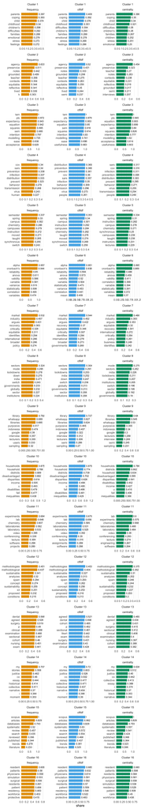

```r
plot(words, value = "share")
```

## Topic sizes

`hg_topic_sizes()` counts the documents of each topic and their share of the clustered documents. With `weights`, a numeric vector named by document, it also reports the weighted size and share; a citation count or a repeat count are typical weights. One row per topic.

```r
sizes <- hg_topic_sizes(hg, topics)
sizes
```

```
        topic   n      share
1   Cluster 1 239 0.06519367
2   Cluster 2 330 0.09001637
3   Cluster 3 161 0.04391708
4   Cluster 4 199 0.05428260
5   Cluster 5 252 0.06873977
6   Cluster 6 232 0.06328423
7   Cluster 7 260 0.07092199
8   Cluster 8 258 0.07037643
9   Cluster 9 272 0.07419531
10 Cluster 10 258 0.07037643
11 Cluster 11 247 0.06737589
12 Cluster 12 237 0.06464812
13 Cluster 13 174 0.04746318
14 Cluster 14 237 0.06464812
15 Cluster 15 142 0.03873432
16 Cluster 16 168 0.04582651
```

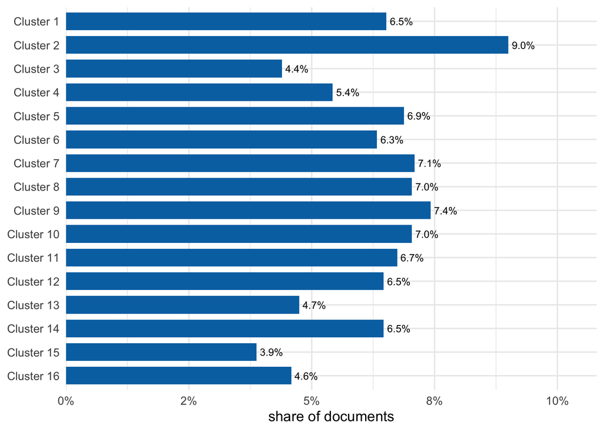

```r
plot(sizes)
```

## Topic coherence and exclusivity

`hg_topic_quality()` scores each topic’s owned vocabulary on two axes. Coherence is the mean normalised pointwise mutual information between pairs of the topic’s top words, computed on their co-occurrence within the topic’s documents: 1 when the words always occur together, 0 at independence, negative when they avoid each other. Exclusivity is the mean share of the same words, the fraction of each word’s corpus count that the topic holds. The top words are the ten that `hg_keywords()` ranks by share with the support floor given.

```r
quality <- hg_topic_quality(hg, topics, min_docs = 15)
quality
```

```
        topic size n_words    coherence exclusivity
1   Cluster 1  239      10 -0.047293805   0.3205238
2   Cluster 2  330      10 -0.208067868   0.4031080
3   Cluster 3  161      10  0.164201835   0.8436658
4   Cluster 4  199      10 -0.079239909   0.3029884
5   Cluster 5  252      10 -0.047800650   0.2840989
6   Cluster 6  232      10  0.069183915   0.6320145
7   Cluster 7  260      10 -0.103198902   0.3581466
8   Cluster 8  258      10 -0.056808873   0.2601943
9   Cluster 9  272      10 -0.070073956   0.4912320
10 Cluster 10  258      10 -0.195760721   0.6039255
11 Cluster 11  247      10  0.009772599   0.4654039
12 Cluster 12  237      10 -0.133264469   0.3070124
13 Cluster 13  174      10 -0.086676140   0.4877552
14 Cluster 14  237      10 -0.110354332   0.4541663
15 Cluster 15  142      10  0.094387058   0.5193813
16 Cluster 16  168      10  0.092126455   0.5110363
```

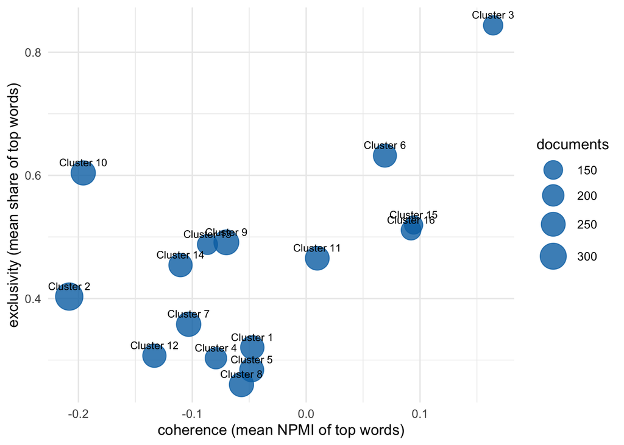

```r
plot(quality)
```

## Soft membership

`hg_membership()` turns the hard partition into a membership of every document in every topic. Documents are placed in the spectral embedding that `hg_cluster()` cut, each topic’s centre is the mean position of its documents, and a document’s membership in a topic is the fuzzy c-means weight with fuzziness 2, the inverse squared distance to the centre normalised over topics. A document at a centre has membership 1 there; one halfway between two centres has 0.5 in each. One row per document and topic.

```r
membership <- hg_membership(hg, topics)
head(membership, 16)
```

```
    node   cluster      topic membership
1  doc_1 Cluster 1  Cluster 1 0.14525086
2  doc_1 Cluster 1  Cluster 2 0.11376072
3  doc_1 Cluster 1  Cluster 3 0.03601903
4  doc_1 Cluster 1  Cluster 4 0.05888968
5  doc_1 Cluster 1  Cluster 5 0.04585866
6  doc_1 Cluster 1  Cluster 6 0.04839670
7  doc_1 Cluster 1  Cluster 7 0.06661422
8  doc_1 Cluster 1  Cluster 8 0.04773057
9  doc_1 Cluster 1  Cluster 9 0.05568981
10 doc_1 Cluster 1 Cluster 10 0.08870426
11 doc_1 Cluster 1 Cluster 11 0.03677184
12 doc_1 Cluster 1 Cluster 12 0.05971312
13 doc_1 Cluster 1 Cluster 13 0.03794299
14 doc_1 Cluster 1 Cluster 14 0.05168538
15 doc_1 Cluster 1 Cluster 15 0.05898602
16 doc_1 Cluster 1 Cluster 16 0.04798614
```

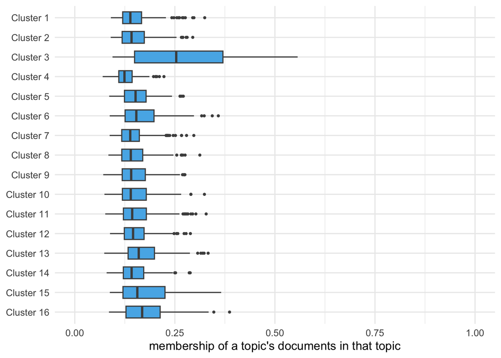

```r
plot(membership)
```

The memberships sum to one over the sixteen topics, so the uniform value is 0.0625 and a document’s own-topic membership of 0.15 is 2.3 times that. They are read as ratios between topics: the first document above is 1.3 times closer to topic 1 than to topic 2 and four times closer than to topic 3. For the median document the nearest centre is 17% closer than the second nearest, so most abstracts lie near a boundary between topics; the hard label records the side they fell on. The plot shows, per topic, the distribution of its own documents’ membership in it. A compact topic has its documents well above the uniform value; a diffuse topic sits close to it.

## Relations between topics

`hg_relations()` builds the topic-by-topic co-occurrence network through shared vocabulary. For each pair of topics it sums, over all words, the product of the number of documents in each topic that contain the word, the full-counting aggregation of bibliometric keyword networks. The `similarity` argument normalises that sum by the measures of van Eck and Waltman (2009); `"cosine"` divides it by the geometric mean of the two topics’ totals and lies in [0, 1]. The function returns an edge list with `source`, `target` and `weight`, the columns Gephi reads, and with `what = "network"` a `cograph_network`.

```r
relations <- hg_relations(hg, topics, similarity = "cosine")
head(relations)
```

```
     source    target    weight
1 Cluster 1 Cluster 2 0.8733272
2 Cluster 1 Cluster 3 0.7761975
3 Cluster 1 Cluster 4 0.8049197
4 Cluster 1 Cluster 5 0.8245490
5 Cluster 1 Cluster 6 0.8391268
6 Cluster 1 Cluster 7 0.7523326
```

Every pair of topics shares the corpus vocabulary, so all 120 cosine weights lie between 0.58 and 0.90. The plot keeps the upper quartile of the edges (`minimum = 0.82`), places the topics with a spring layout and scales line width by weight.

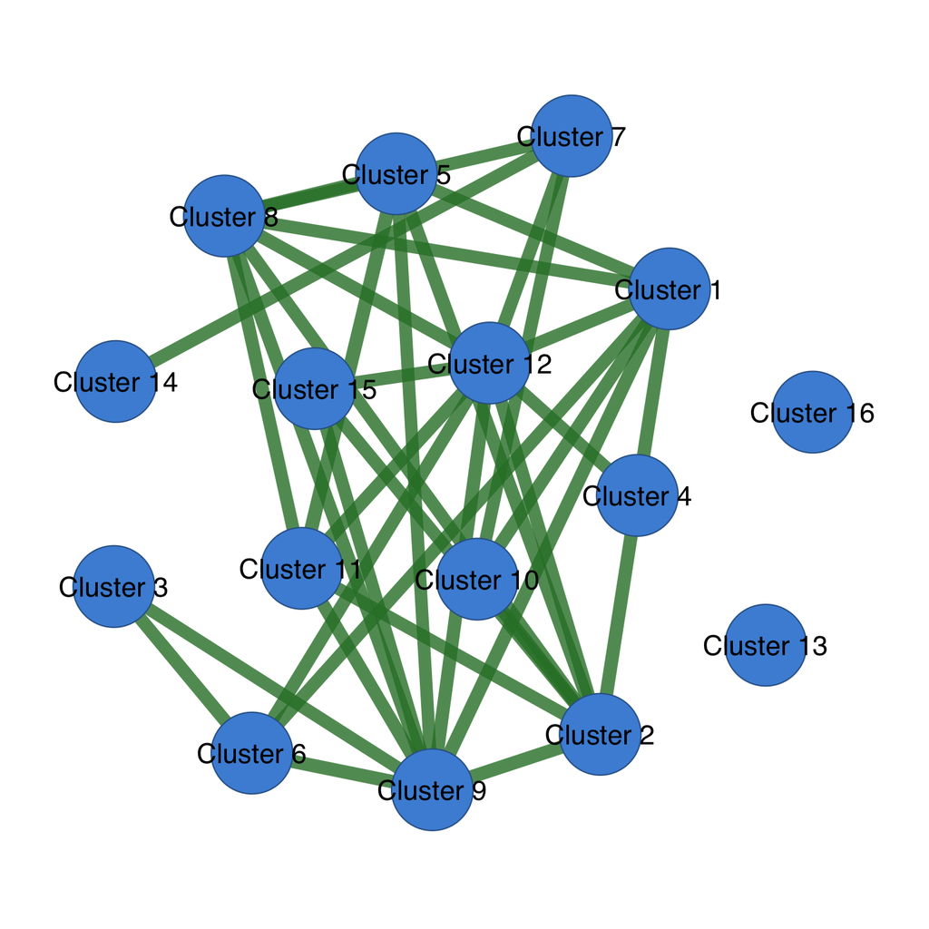

```r
network <- hg_relations(hg, topics, similarity = "cosine", what = "network")
cograph::splot(network, layout = "spring", minimum = 0.82,
               edge_width_range = c(0.5, 8))
```

## Summary

The pipeline produced sixteen document clusters from 3,666 abstracts without embeddings or truncation. The spectrum of the hypergraph Laplacian supports two or four clusters; the finer partition was chosen to match a published topic model. Ranking words by the share of their corpus count that falls in a cluster, with a support floor, yields a distinct vocabulary for each cluster, whereas ranking by frequency yields the corpus vocabulary for all of them.

## References

Grootendorst, M. (2022). BERTopic: Neural topic modeling with a class-based TF-IDF procedure. arXiv:2203.05794.

Saqr, M., Raspopovic Milic, M., Pancheva, K., Jovic, J., Peltekova, E. V., and Conde, M. Á. (2023). A multimethod synthesis of Covid-19 education research: the tightrope between covidization and meaningfulness. Universal Access in the Information Society.

van Eck, N. J., and Waltman, L. (2009). How to normalize cooccurrence data? An analysis of some well-known similarity measures. Journal of the American Society for Information Science and Technology, 60(8), 1635-1651.

Bezdek, J. C. (1981). Pattern Recognition with Fuzzy Objective Function Algorithms. Plenum.

Bouma, G. (2009). Normalized (pointwise) mutual information in collocation extraction. Proceedings of GSCL, 31-40.

Zhou, D., Huang, J., and Schölkopf, B. (2007). Learning with hypergraphs: clustering, classification, and embedding. Advances in Neural Information Processing Systems 19.